# <i class="fas fa-tools"></i> <code>shinyRFate</code> tool box

See [RFATE()](../reference/RFATE.html) function

`RFate` workflow, presented on Home page, is quite long and complex. Although it can be divided into **4 main parts**, each of them requires several steps, and the user can quickly get lost or confused in the whole process.

The organization of the Reference page, as well as the order of the tutorials, try to reflect these different parts.

A [shiny](https://shiny.rstudio.com/) interface, that can be launched with the RFATE() function from the `RFate` package allows the user to go through the different steps without going through the code. Links to the *functions documentation*, *vizualization tools*, the possibility to *start from pre-existing folders*, always being able to follow the *progress in the console* of the different functions… This interface should make it easier to take control of `FATE` with R.

[figure not shown]

## `shinyRFate` tool box

#### Help and documentation

Two types of documentation can be accessed all over the application through buttons. They give informations about :

- the different steps to be followed in each part  
  (global informations that can be found in the tutorials, about the different `FATE` modules for example)

[figure not shown]

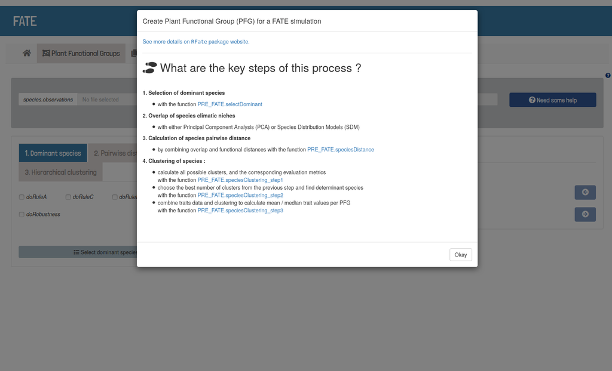

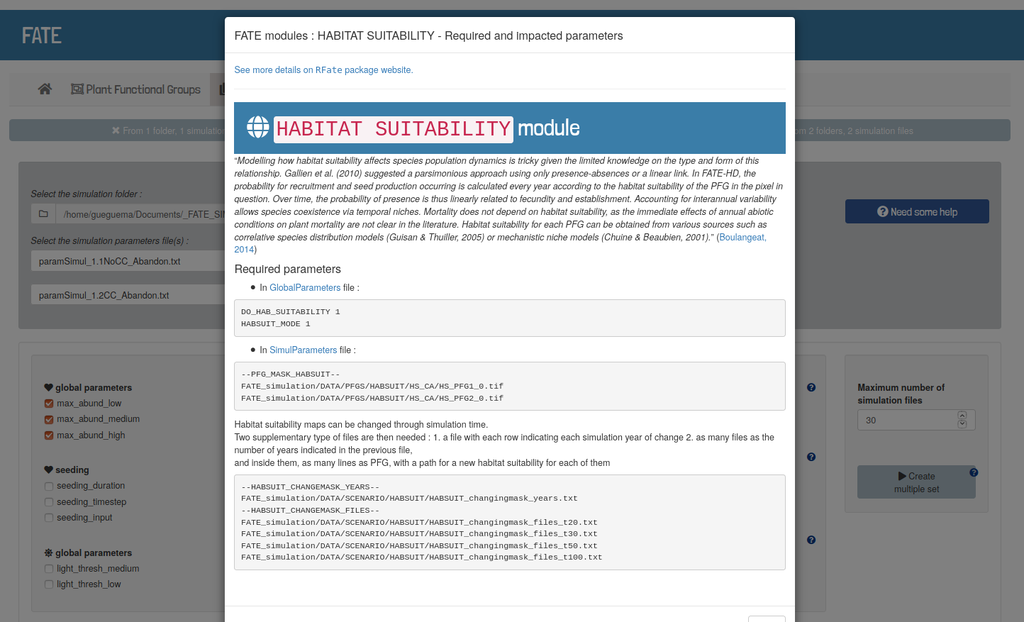

- the different parameters needed by the available functions, and redirection to more complete documentation (see Reference page)

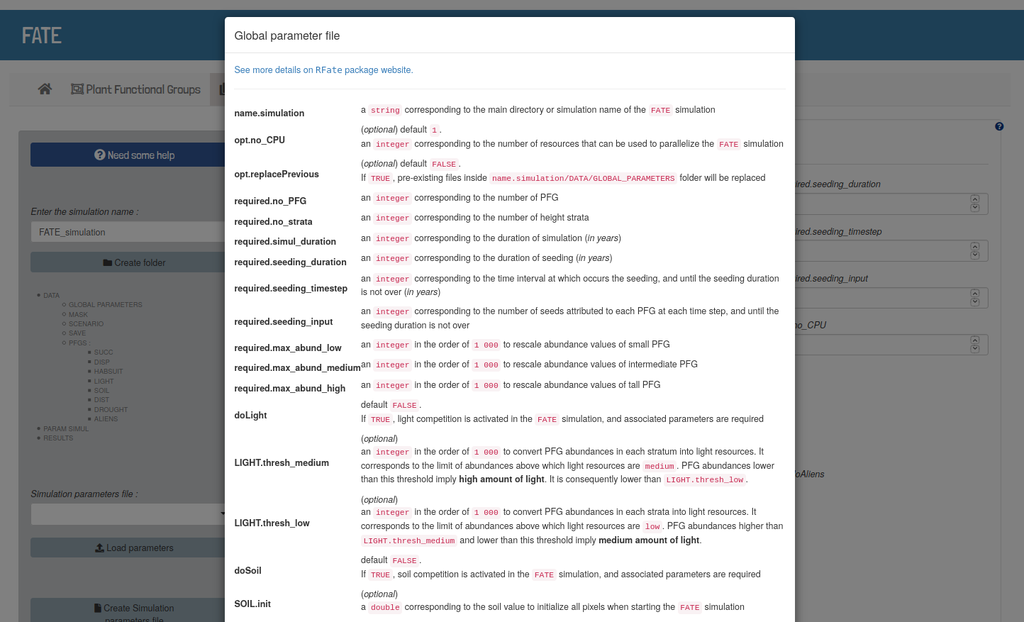

#### Monitoring of functions

Once a button was pressed to start a function, a panel is displayed as long as the function is running, indicating the selected parameters. All informations printed by the function can be followed within the `R` console. Information panels appear when the functions has finished running, results files have been created, or an error has been found.

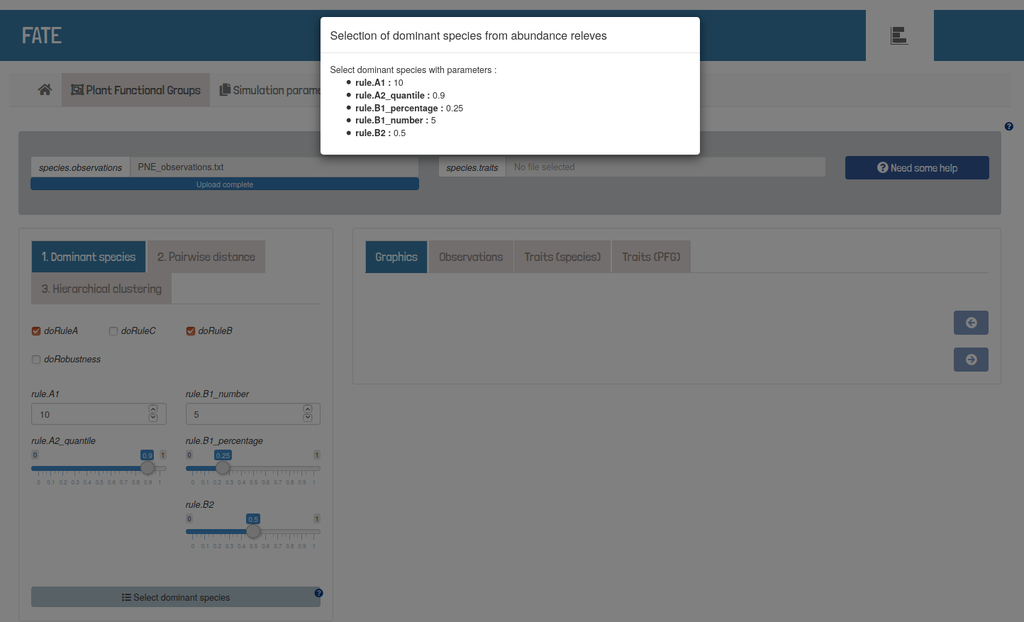

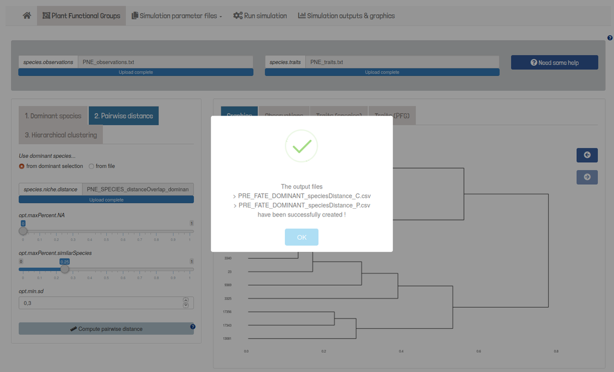

## `shinyRFate` workflow

#### Plant Functional Groups

Created graphics and tables of loaded and used values can be visualized through the application.  
Generally, the data shown onto the shiny application is saved into `.csv` or `.pdf` files.

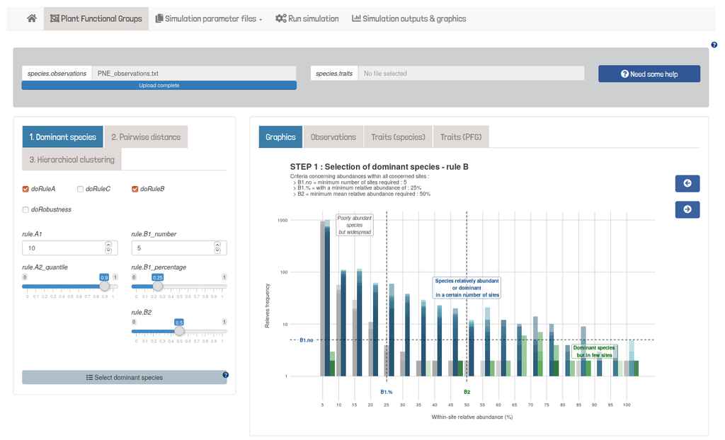

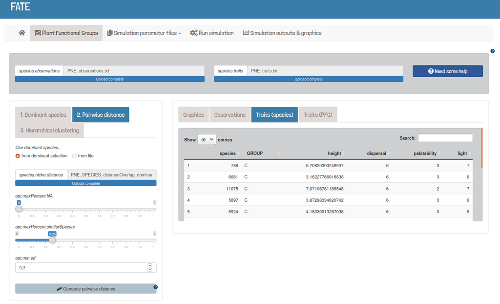

#### Simulation parameter files

Parameter files and folders can be created, visualized and modified from the application.  
Multiple sets of parameters can be produced from a pre-existing simulation folder.

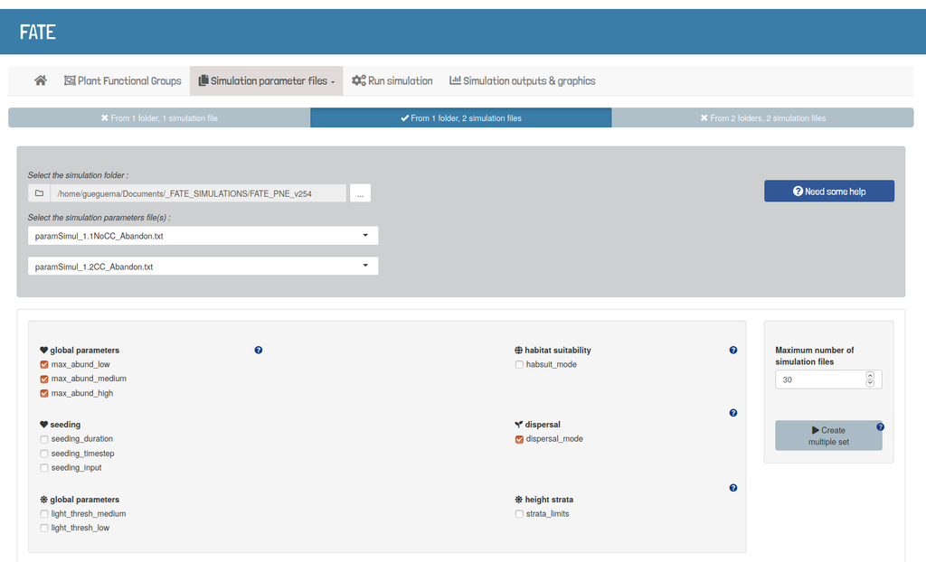

#### Run a FATE simulation

`C++` model is run through `R` with the `Rcpp` package. Outputs and log errors can be visualized in the application or the `R` console.

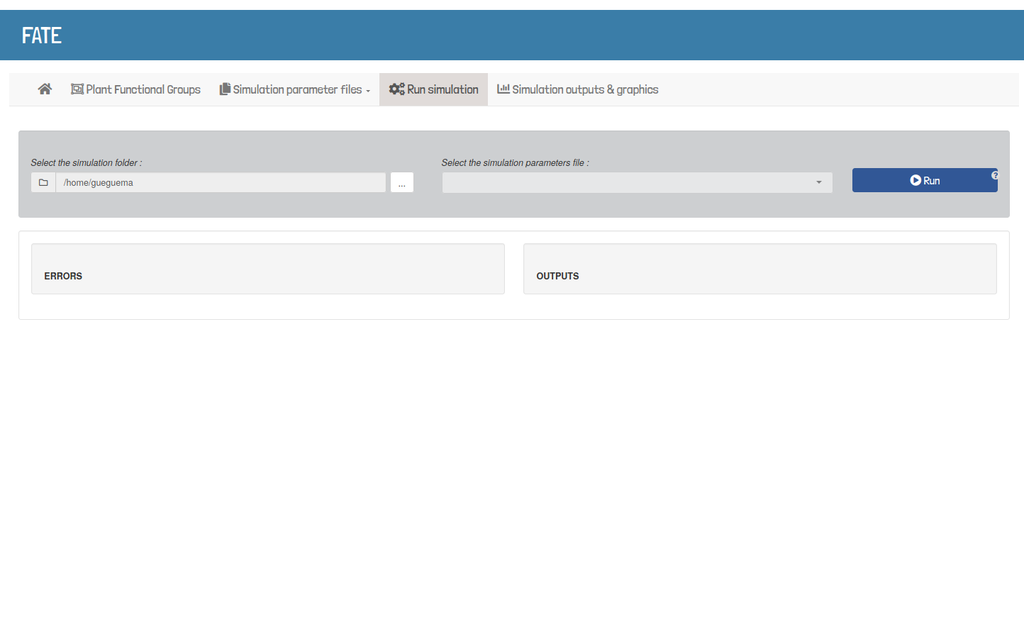

#### Analyse results

`RFate` package provides functions to pre-analyse results of `FATE` simulations. It can produce intermediate results files, quick summary graphics, and preliminary transformation of outputs. Existing graphics can be re-viewed with the browser panel.

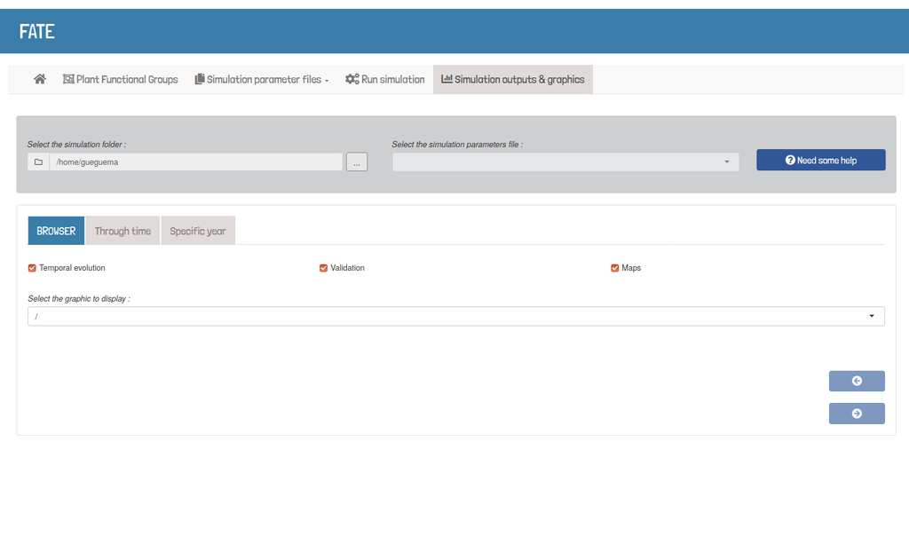

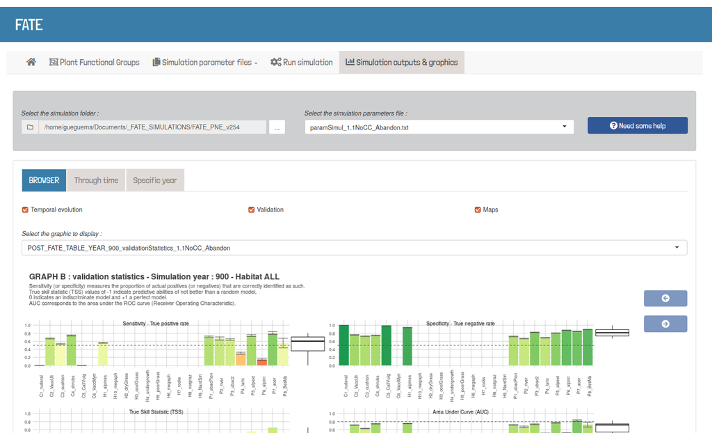

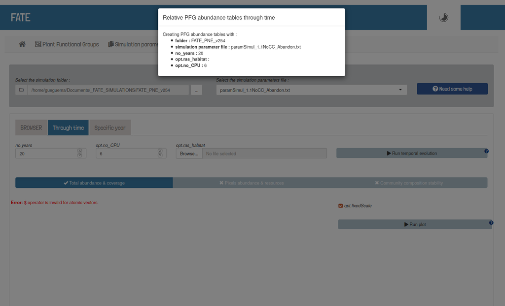

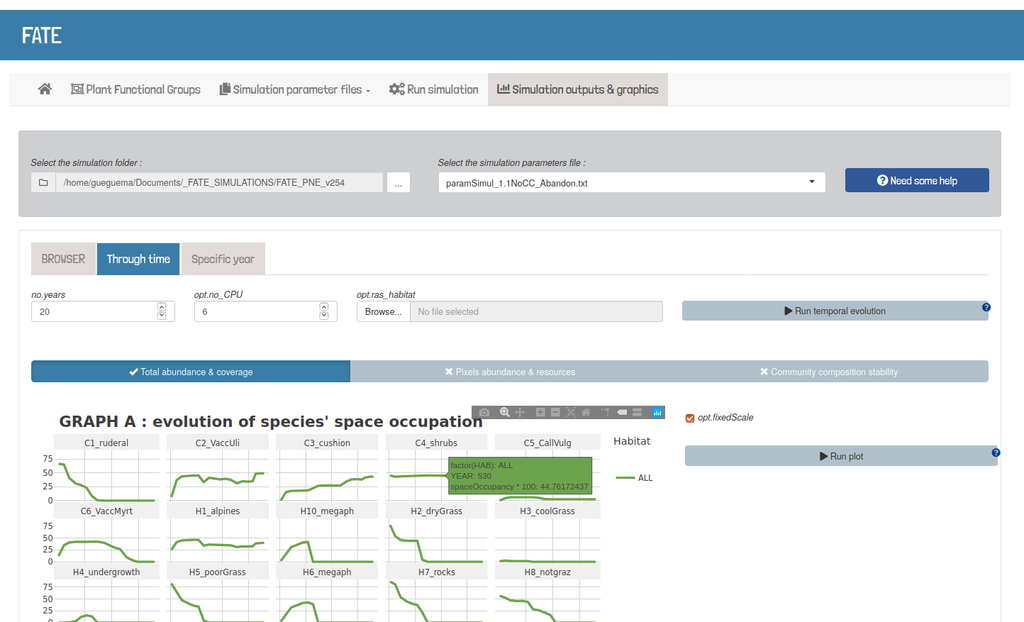

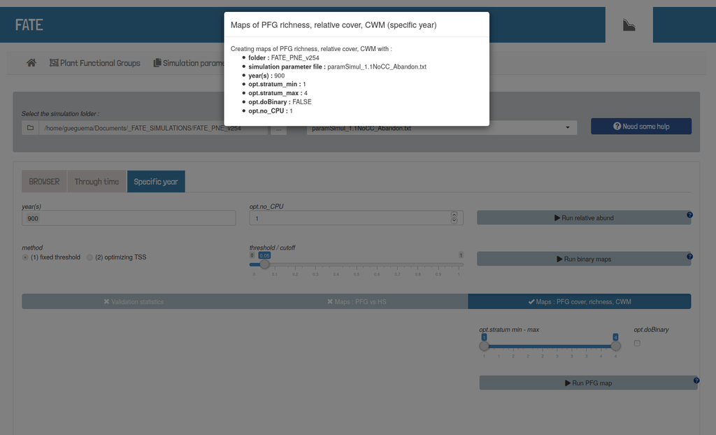

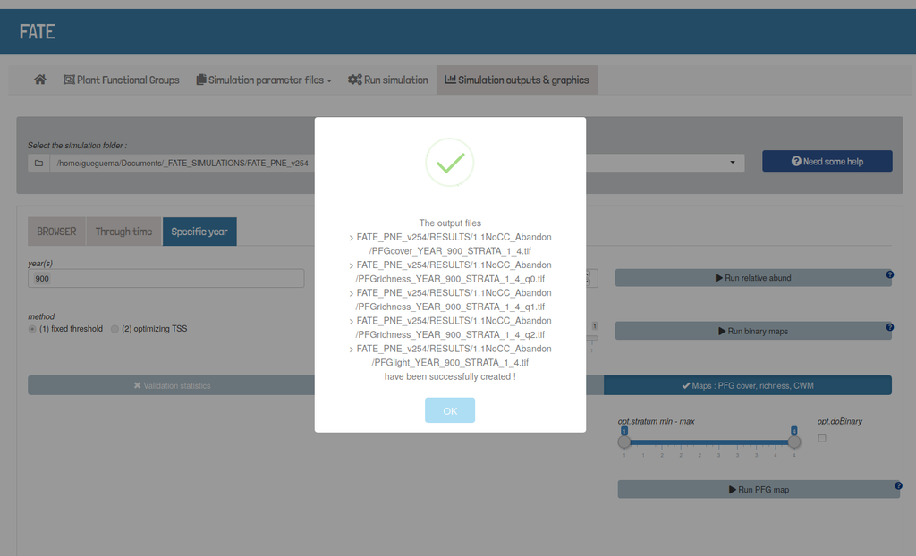